# Practica Final Modulo 5. Victor Manuel Ferreira Martinez

- En este caso no hemos intentado hacer un bucle para la visualización, debido a que se necesitan ir cambiando la escala de los gráficos para visualizarlos correctamente. Y tampoco se utiliza la funcion par(), ya que no ayuda a la visualización.

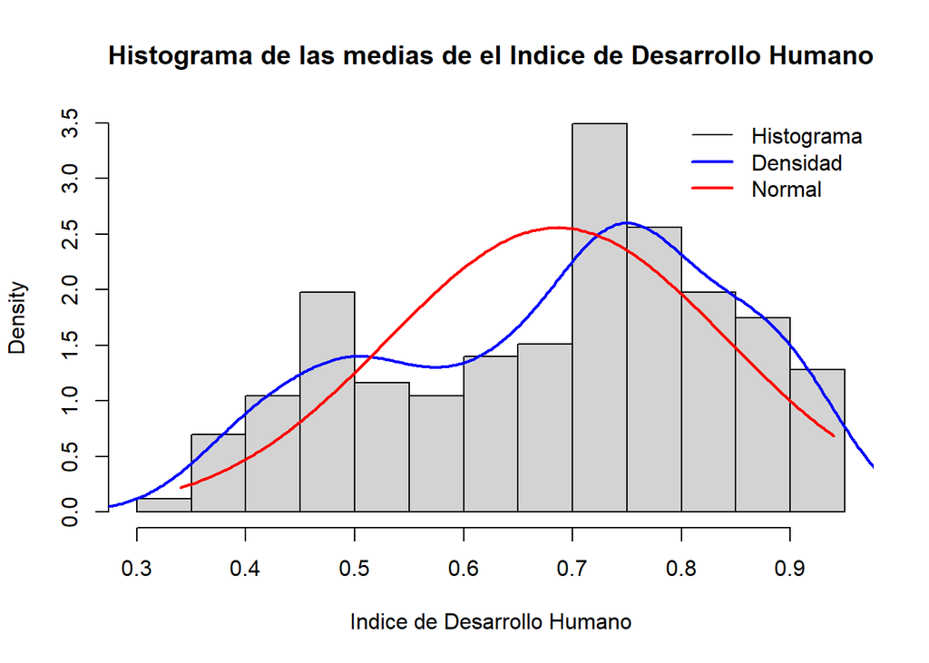

```r
histDenNorm(idh$HDI, prob = TRUE, main = "Histograma de las medias de el Indice de Desarrollo Humano", xlab = "Indice de Desarrollo Humano")
```

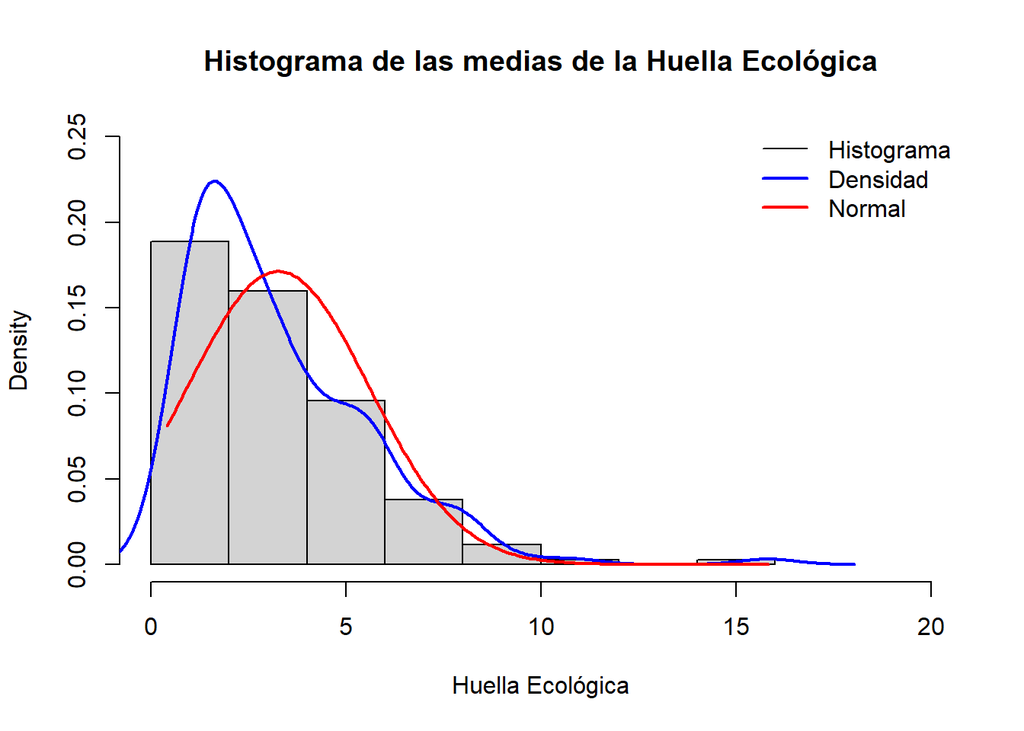

```r
histDenNorm(idh$`Total Ecological Footprint`, prob = TRUE, main = "Histograma de las medias de la Huella Ecológica", xlab = "Huella Ecológica", ylim = c(0, 0.25), xlim = c(0,20))
```

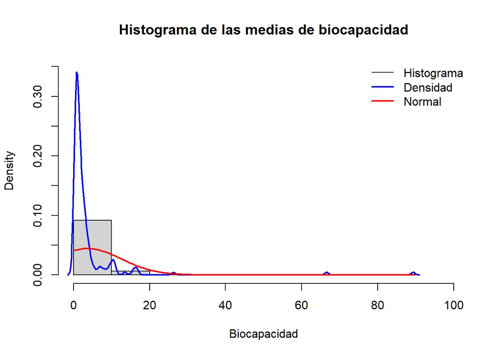

```r
histDenNorm(idh$`Total Biocapacity`, prob = TRUE, main = "Histograma de las medias de biocapacidad", xlab = "Biocapacidad", ylim = c(0, 0.35), xlim = c(0, 100))
```

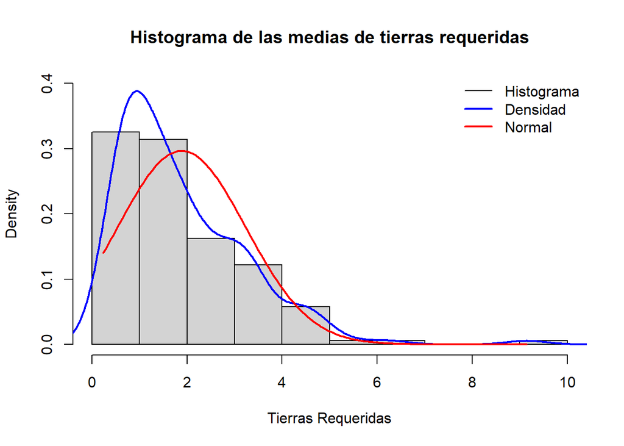

```r
histDenNorm(idh$`Earths Required`, prob = TRUE, main = "Histograma de las medias de tierras requeridas", xlab = "Tierras Requeridas", ylim = c(0, 0.40), xlim = c(0,10))
```

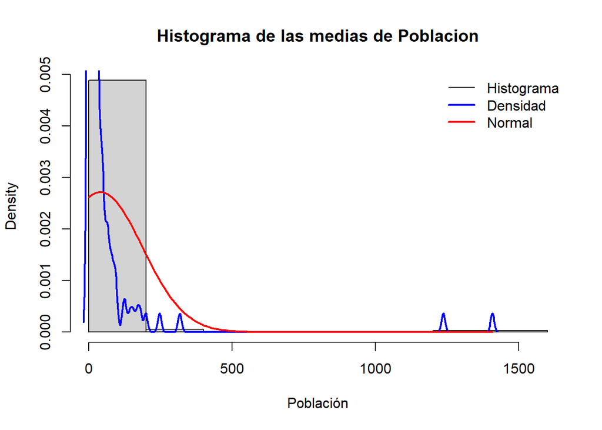

```r
histDenNorm(idh$Poblacion, prob = TRUE, main = "Histograma de las medias de Poblacion", xlab = "Población")
```

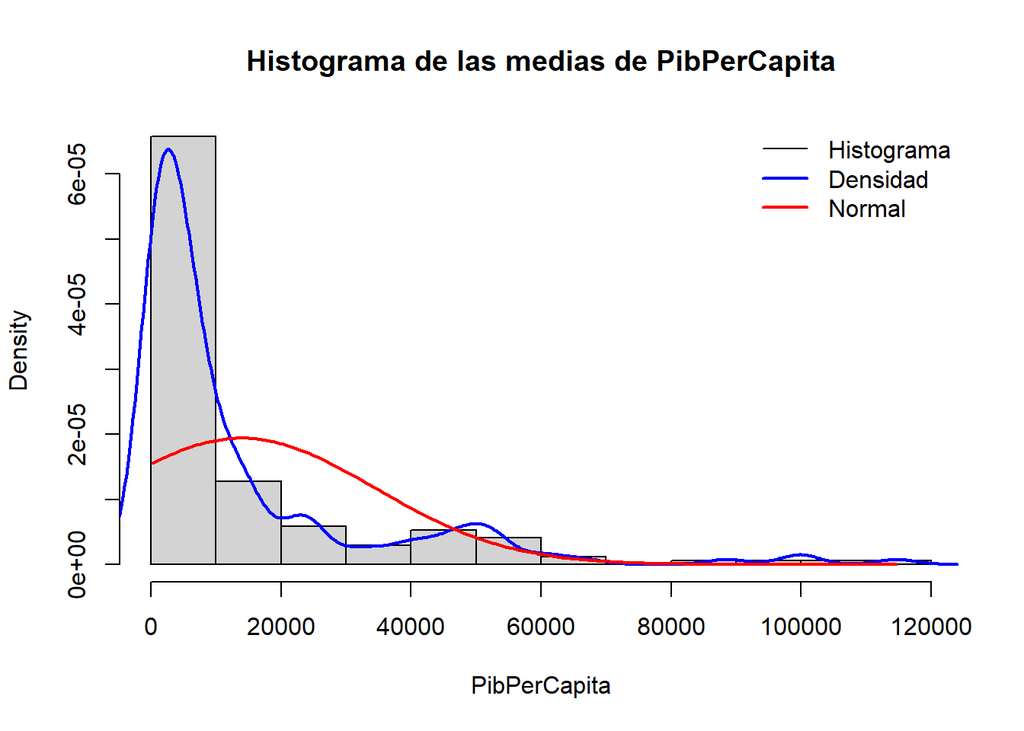

```r
histDenNorm(idh$PibPerCap_, prob = TRUE, main = "Histograma de las medias de PibPerCapita", xlab = "PibPerCapita")
```

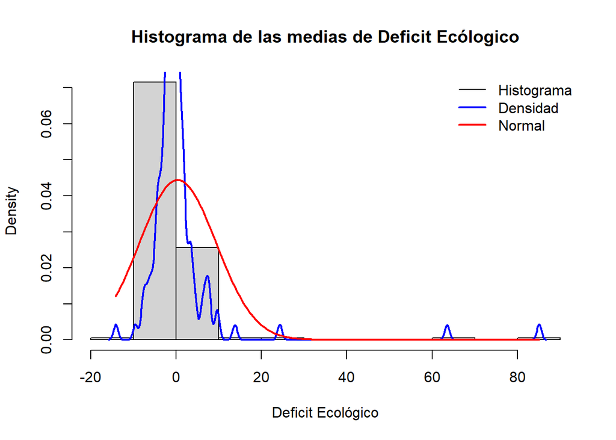

```r
histDenNorm(idh$`Biocapacity Deficit or Reserve`, prob = TRUE, main = "Histograma de las medias de Deficit Ecólogico", xlab = "Deficit Ecológico")
```

*Tras comprobar de manera visual, vamos a proceder a realizar diferentes tests para confirmar que efectivamente las variables del estudio, no siguen una distribución normal.*

- Se utiliza un Shapiro test, sin necesidad de coger un numero determinado de valores, ya que el data frame cuenta con 172, y este test da resultado entre 3 y 5000.

```r
valores <- idh %>% dplyr::select("Poblacion", "HDI","Total Ecological Footprint", "Total Biocapacity", "Biocapacity Deficit or Reserve", "Earths Required", "PibPerCap_")

sapply(valores, function(x) round(shapiro.test(x)$p.value,2))
```

```
##                      Poblacion                            HDI
##                              0                              0
##     Total Ecological Footprint              Total Biocapacity
##                              0                              0
## Biocapacity Deficit or Reserve                Earths Required
##                              0                              0
##                     PibPerCap_
##                              0
```

- La decisión de usar este test, se debe a que salvo error, otros test conocidos como **Chi-Cuadrado** o **Kologomov-Smirnov** parecen ajustarse peor para ver si la distribucion de las diferentes es variables es normal. Como se puede ver, en todos los casos el p-value es muy inferior a los niveles de significación, por tanto si:

**H0: La distribución es normal.** **H1: La distribución no es normal,**

Hay suficientes evidencias para rechazar la hipotesis nula, y por tanto ninguna de las variables parece seguir una distribución normal.

- A partir de aquí, y para evitar que el futuro modelo de regresión se adecue bien a analizar nuestros datos, o otras pruebas que queramos hacer, vamos a hacer dos cosas:
1. Visualización de la posible relación entre las diferentes variables.
2. Normalización de las variables y comrpobación posterior a traves de la visualización de la relación lineal para ver posibles variaciones.

```r
idh.cor <- idh %>%dplyr:: select("Poblacion", "HDI","Total Ecological Footprint", "Total Biocapacity", "Biocapacity Deficit or Reserve", "Earths Required", "PibPerCap_")
mat.idh.cor <- cor(idh.cor, method = "pearson")
round(mat.idh.cor, 6)
```

```
##                                Poblacion       HDI Total Ecological Footprint
## Poblacion                       1.000000 -0.002684                  -0.053366
## HDI                            -0.002684  1.000000                   0.739086
## Total Ecological Footprint     -0.053366  0.739086                   1.000000
## Total Biocapacity              -0.057161  0.077711                   0.134619
## Biocapacity Deficit or Reserve -0.043439 -0.113610                  -0.124218
## Earths Required                -0.053312  0.739072                   0.999997
## PibPerCap_                     -0.046619  0.677872                   0.802436
##                                Total Biocapacity Biocapacity Deficit or Reserve
## Poblacion                              -0.057161                      -0.043439
## HDI                                     0.077711                      -0.113610
## Total Ecological Footprint              0.134619                      -0.124218
## Total Biocapacity                       1.000000                       0.966501
## Biocapacity Deficit or Reserve          0.966501                       1.000000
## Earths Required                         0.134621                      -0.124216
## PibPerCap_                              0.050244                      -0.157529
##                                Earths Required PibPerCap_
## Poblacion                            -0.053312  -0.046619
## HDI                                   0.739072   0.677872
## Total Ecological Footprint            0.999997   0.802436
## Total Biocapacity                     0.134621   0.050244
## Biocapacity Deficit or Reserve       -0.124216  -0.157529
## Earths Required                       1.000000   0.802375
## PibPerCap_                            0.802375   1.000000
```

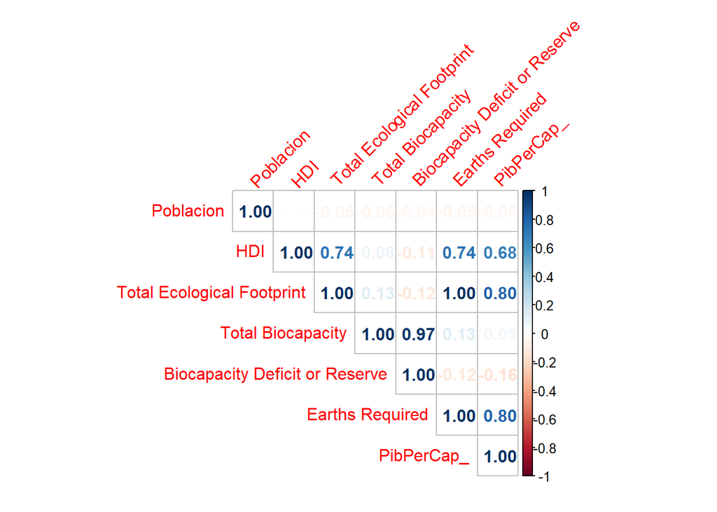

```r
corrplot(mat.idh.cor, tl.srt = 45, method = "number", addshade = "all", type = "upper")
```

- **HDI VS TOTAL ECOLOGICAL FOOTPRINT** - Como se puede observar la correlación entre estas dos variables es alta, por tanto podemos empezar a intuir que existe una variación sistematica de una frente a la otra.

- **HDI VS TIERRAS REQUERIDAS** - La relacion entre la cantidad de tierras requeridas y la huella ecológica total es total como era de esperar. Esto se debe a que el requerimiento ecológico que marca la huella total se transforma en cantidad de tierras atendiendo a este requerimiento, por eso la variable tiene una relacion similar con el HDI.
- **HDI VS PibPerCap** - La relación entre estas dos variables es muy interesante. Al ser positiva, podriamos decir que existe una variación sistemática de estas dos variables, lo cual explicaría como el PIB esta intimamente ligado al nivel de desarrollo que vendría a expresar el HDI. A su vez, la huella ecólogica total estaría también muy relacionada con el PibPerCap, lo que indicaría que a mayor Pib, mayor requerimiento ecólogico de los paises..
- No existe relación aparente de las demas variables con el indice de desarrollo humano..
- Podriamos añadir que puede existir cierta coolinealidad entre el total de biocapacidad y el deficit ecólogico, por tanto en una análisis de regresión lineal multiple, seria necesario tener esto en cuenta.

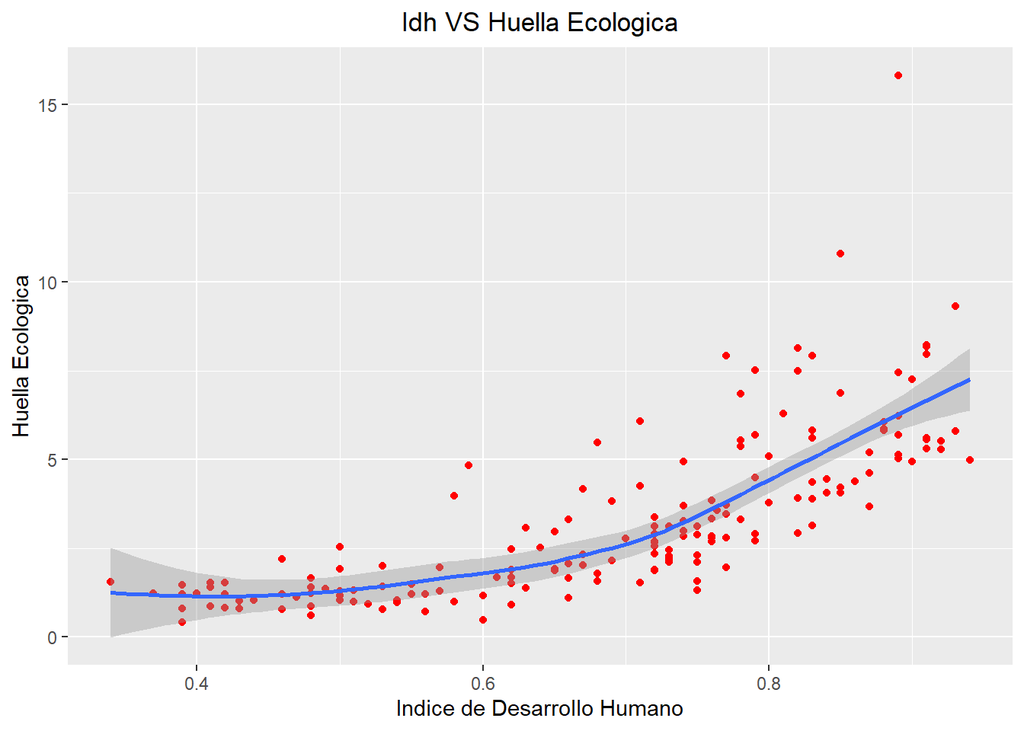

```r
ggplot(idh, aes(HDI, `Total Ecological Footprint`)) +
  geom_point(col = "red") +
  stat_smooth() +
  ggtitle("Idh VS Huella Ecologica") +
  theme(plot.title = element_text(hjust = 0.5)) +
          labs(x = "Indice de Desarrollo Humano", y = "Huella Ecologica")
```

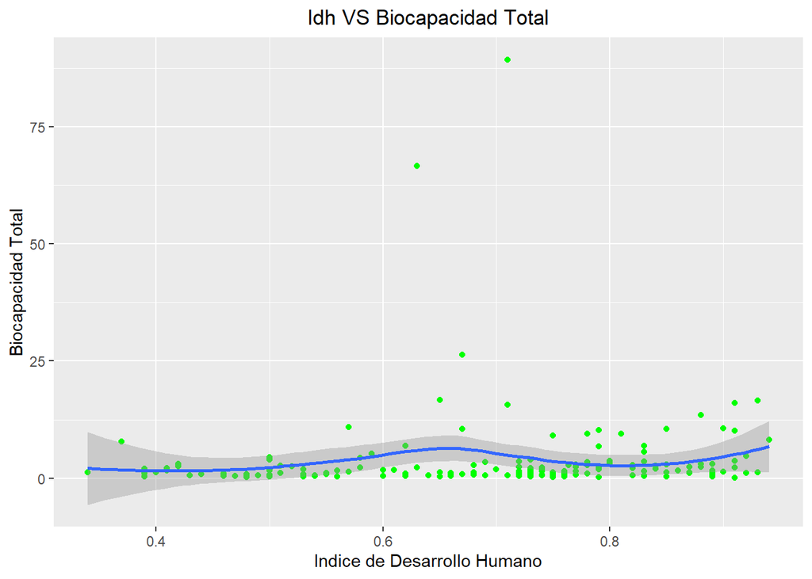

```r
ggplot(idh, aes(HDI, `Total Biocapacity`)) +
  geom_point(col = "green") +
  stat_smooth() +
  ggtitle("Idh VS Biocapacidad Total") +
  theme(plot.title = element_text(hjust = 0.5)) +
          labs(x = "Indice de Desarrollo Humano", y = "Biocapacidad Total")
```

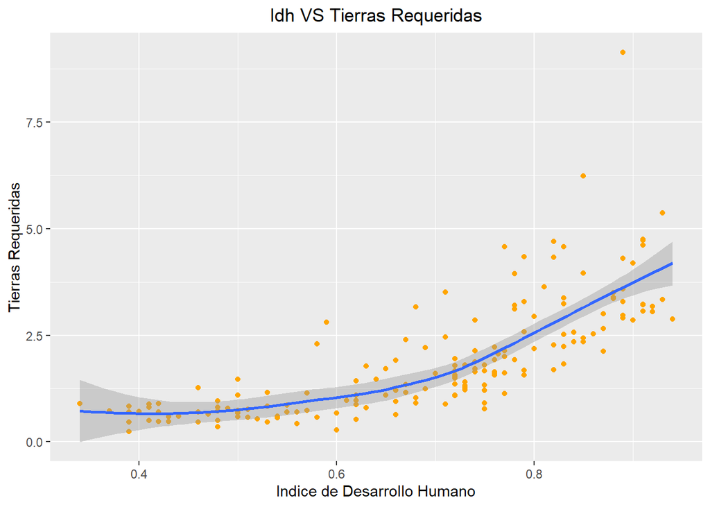

```r
ggplot(idh, aes(HDI, `Earths Required`)) +
  geom_point(col = "orange") +
  stat_smooth() +
  ggtitle("Idh VS Tierras Requeridas") +
  theme(plot.title = element_text(hjust = 0.5)) +
          labs(x = "Indice de Desarrollo Humano", y = "Tierras Requeridas")
```

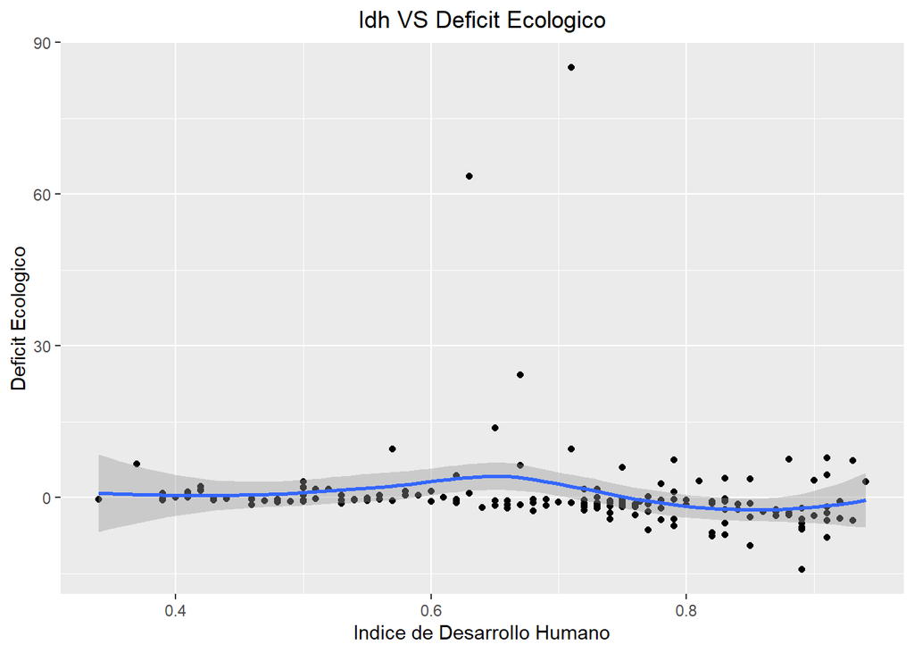

```r
ggplot(idh, aes(HDI, `Biocapacity Deficit or Reserve`), col = "red") +
  geom_point(col = "black") +
  stat_smooth() +
  ggtitle("Idh VS Deficit Ecologico") +
  theme(plot.title = element_text(hjust = 0.5)) +
          labs(x = "Indice de Desarrollo Humano", y = "Deficit Ecologico")
```

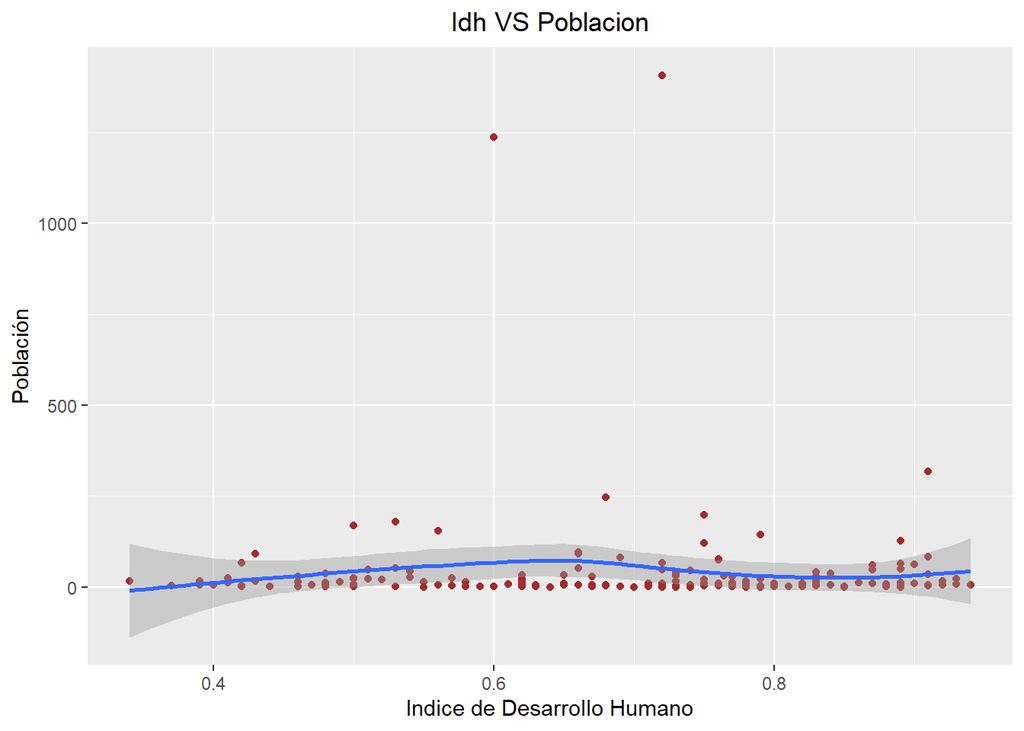

```r
ggplot(idh, aes(HDI, Poblacion), col = "red") +
  geom_point(col = "brown") +
  stat_smooth() +
  ggtitle("Idh VS Poblacion") +
  theme(plot.title = element_text(hjust = 0.5)) +
          labs(x = "Indice de Desarrollo Humano", y = "Población")
```

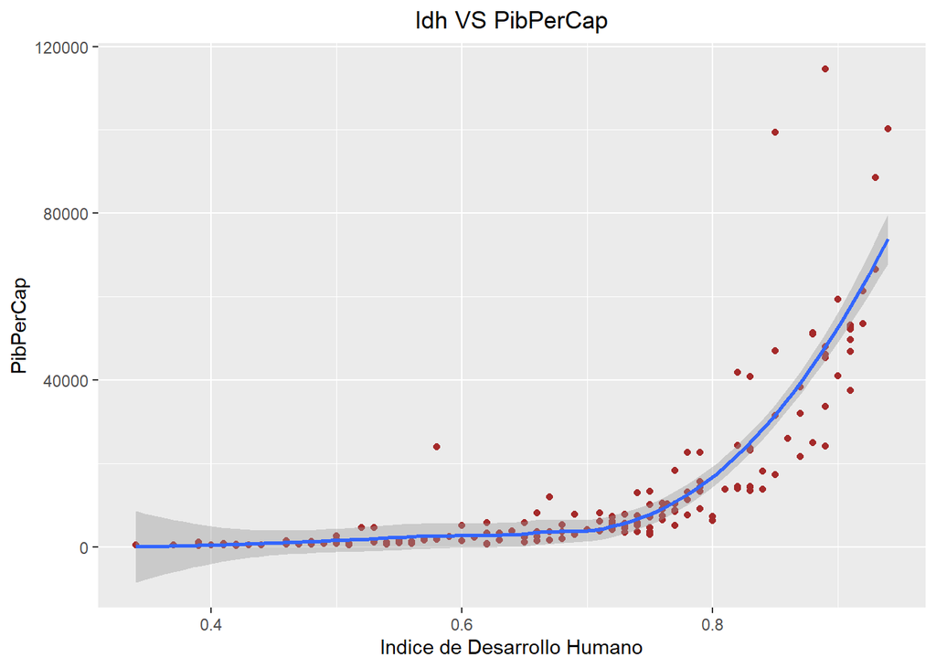

```r
ggplot(idh, aes(HDI, PibPerCap_), col = "red") +
  geom_point(col = "brown") +
  stat_smooth() +
  ggtitle("Idh VS PibPerCap") +
  theme(plot.title = element_text(hjust = 0.5)) +
          labs(x = "Indice de Desarrollo Humano", y = "PibPerCap")
```

- Es necesario tener en cuenta que la huella ecológica es la superficie total de tierra medida en hectareas productivas necesarias para producir los recursos consumidos por el ciudadano medio de un pais, esto en suma da una medida de cuantas tierras necesitaria un pais, si todo el mundo consumiera como lo hacen sus ciudadanos medios. Por tanto, es logico encontrar una relación entre ambas variables, refiriendonos a **Huella Ecologica Total** con la **Cantidad de Tierras Requeridas**, y estas a su vez con el **HDI**

-La biocapacidad total sin embargo, es la capacidad que tiene cierta area especifica, en este caso volveremos a utilizar pais, de abastacer regularmente a dicho pais y además de absorber los residuos resultantes de dicho consumo, por esta razón la relación con las demas variables ya no es tan estrecha, debido a que el requerimiento no condiciona la capacidad de cubrir ese requerimiento, y de ahí su escasa relación.

- Una de las posibilidades para que los modelos de regresión con estas variables sean mas robustos, es normalizar dichas variables.

```r
IdhNorm <- scale(idh$`Total Ecological Footprint`, center = T, scale = T)
TotEcFootNorm <- scale(idh$`Total Ecological Footprint`, center = T, scale = T)
TotBiocapacityNorm <- scale(idh$`Total Biocapacity`, center = T, scale = T)
TotEarthReqNorm <- scale(idh$`Earths Required`, center = T, scale = T)
TotDefBiocResNorm <- scale(idh$`Biocapacity Deficit or Reserve`, center = T, scale = T)
TotPobNorm <- scale(idh$Poblacion, center = T, scale = T)
TotPibPerNorm <- scale(idh$PibPerCap_, center = T, scale = T)
idh_norm <- data.frame(IdhNorm, TotEcFootNorm, TotEarthReqNorm, TotDefBiocResNorm, TotPobNorm, TotPibPerNorm)
```

[figure not shown]

```r
par(mfrow = c(2,3))

plot(IdhNorm , TotEcFootNorm, main = "Relación Lineal", col = "orange", ylab = "Huella Ecologica Total", xlab= "Indice de Desarrollo Humano")
abline(lm(IdhNorm ~TotEcFootNorm))

plot(IdhNorm , TotBiocapacityNorm, main = "Relación Lineal", col = "blue", ylab = "Biocapacidad", xlab= "Indice de Desarrollo Humano")
abline(lm(IdhNorm ~TotBiocapacityNorm))

plot(IdhNorm, TotEarthReqNorm, main = "Relación Lineal", col = "green", ylab = "Tierras Requeridas", xlab= "Indice de Desarrollo Humano")
abline(lm(IdhNorm ~TotEarthReqNorm))

plot(IdhNorm, TotDefBiocResNorm, main = "Relación Lineal", col = "green", ylab = "Deficit Ecólogico", xlab= "Indice de Desarrollo Humano")
abline(lm(IdhNorm~TotDefBiocResNorm))

plot(IdhNorm, TotPobNorm, main = "Relación Lineal", col = "green", ylab = "Población", xlab= "Indice de Desarrollo Humano")
abline(lm(IdhNorm~TotPobNorm))

plot(IdhNorm, TotPibPerNorm, main = "Relación Lineal", col = "green", ylab = "PibPerCap", xlab= "Indice de Desarrollo Humano")
abline(lm(IdhNorm~TotPibPerNorm))
```

```r
idh_model <- idh
idh_model$HDI_CAT <- NULL
idh_model$Country <- NULL
idh_model$Region <- NULL
```

- Modelo de seleccion de variables stepAic, sin normalizar

```r
fit.1 <- glm(HDI~., data=idh_model, family= gaussian)
fit.0 <- glm(HDI~1, data=idh, family= gaussian)
step <- stepAIC(fit.0,direction="both",scope=list(upper=fit.1,lower=fit.0))
```

```
## Start:  AIC=-147.92
## HDI ~ 1
##
##                                    Df Deviance     AIC
## + `Total Ecological Footprint`      1   1.8892 -281.83
## + `Earths Required`                 1   1.8893 -281.82
## + PibPerCap_                        1   2.2504 -251.75
## + `Biocapacity Deficit or Reserve`  1   4.1098 -148.15
## <none>                                  4.1636 -147.92
## + `Total Biocapacity`               1   4.1384 -146.96
## + Poblacion                         1   4.1635 -145.92
##
## Step:  AIC=-281.83
## HDI ~ `Total Ecological Footprint`
##
##                                    Df Deviance     AIC
## + PibPerCap_                        1   1.8051 -287.66
## <none>                                  1.8892 -281.83
## + Poblacion                         1   1.8836 -280.35
## + `Total Biocapacity`               1   1.8872 -280.02
## + `Biocapacity Deficit or Reserve`  1   1.8872 -280.02
## + `Earths Required`                 1   1.8891 -279.84
## - `Total Ecological Footprint`      1   4.1636 -147.92
##
## Step:  AIC=-287.66
## HDI ~ `Total Ecological Footprint` + PibPerCap_
##
##                                    Df Deviance     AIC
## <none>                                  1.8051 -287.66
## + Poblacion                         1   1.7992 -286.23
## + `Total Biocapacity`               1   1.8049 -285.69
## + `Biocapacity Deficit or Reserve`  1   1.8049 -285.69
## + `Earths Required`                 1   1.8051 -285.66
## - PibPerCap_                        1   1.8892 -281.83
## - `Total Ecological Footprint`      1   2.2504 -251.75
```

```r
step$formula
```

```
## HDI ~ `Total Ecological Footprint` + PibPerCap_
```

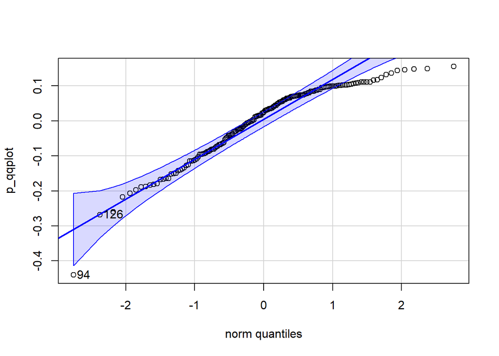

```
## [1]  94 126
```

```r
p_qqplot <- step$residuals
qqPlot(p_qqplot, distribution = "norm")
```

- Modelo de selección de variables stepAic normalizadas

```r
fit.3 <- glm(IdhNorm~., data=idh_norm, family= gaussian)
fit.2 <- glm(IdhNorm~1, data=idh_norm, family= gaussian)
step2 <- stepAIC(fit.2,direction="both",scope=list(upper=fit.3,lower=fit.2))
```

```
## Start:  AIC=491.11
## IdhNorm ~ 1
##
##                     Df Deviance      AIC
## + TotEcFootNorm      1    0.000 -11581.6
## + TotEarthReqNorm    1    0.001  -1558.6
## + TotPibPerNorm      1   60.892    315.5
## + TotDefBiocResNorm  1  168.361    490.4
## <none>                  171.000    491.1
## + TotPobNorm         1  170.513    492.6
##
## Step:  AIC=-11581.59
## IdhNorm ~ TotEcFootNorm
##
##                     Df Deviance      AIC
## <none>                        0 -11581.6
## + TotPobNorm         1        0 -11579.9
## + TotPibPerNorm      1        0 -11579.6
## + TotDefBiocResNorm  1        0 -11579.4
## + TotEarthReqNorm    1        0 -11544.3
## - TotEcFootNorm      1      171    491.1
```

```r
step2$formula
```

```
## IdhNorm ~ TotEcFootNorm
```

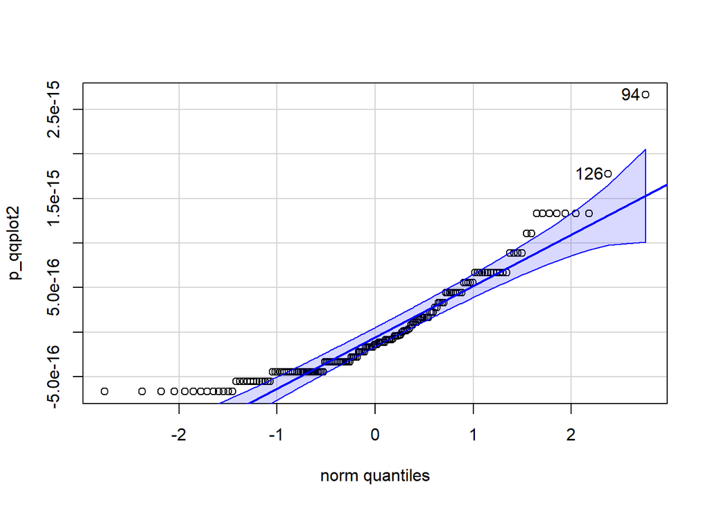

```
## [1]  94 126
```

```r
p_qqplot2 <- step2$residuals
qqPlot(p_qqplot2, distribution = "norm")
```

#### PASO 3.

3.1 Encontrar las técnicas más apropiadas para corroborar las preconclusiones con la ayuda de un mapa. 3.2 Diseñar la metodología de análisis. 3.3 Aplicar esta metodología. 3.4 Resumir los resultados.

3.1. A partir de aquí utilizaremos diferentes técnicas para demostrar la relación entre las dos variables especficadas que hemos advertido con los analisis anteriores. Ademas haremos una comparación multivariable con las otras dos variables que nos hemos permitido comparar durante nuestro estudio.

```r
summary(aov(idh$`Total Ecological Footprint`~idh$HDI_CAT))
```

```
##              Df Sum Sq Mean Sq F value Pr(>F)
## idh$HDI_CAT   3  542.8  180.93   79.25 <2e-16 ***
## Residuals   168  383.5    2.28
## ---
## Signif. codes:  0 '***' 0.001 '**' 0.01 '*' 0.05 '.' 0.1 ' ' 1
```

El p-valor está muy por debajo de p = 0.05, por tanto tenemos evidencias suficientes para rechazar la hipotesis nula. En tal caso se podria afirmar que los valores de Huella Ecólogica Total, cambian segun los diferentes niveles de Indice de Desarrollo Humano. Dicho de otra forma, la huella ecológica varía segun el nivel de desarrollo humano de cada pais.

```r
summary(aov(TotEcFootNorm~idh$HDI_CAT))
```

```
##              Df Sum Sq Mean Sq F value Pr(>F)
## idh$HDI_CAT   3  100.2   33.40   79.25 <2e-16 ***
## Residuals   168   70.8    0.42
## ---
## Signif. codes:  0 '***' 0.001 '**' 0.01 '*' 0.05 '.' 0.1 ' ' 1
```

El p-valor con la variable normalizada es exactamente el mismo.

```r
summary(aov(idh$PibPerCap_~idh$HDI_CAT))
```

```
##              Df    Sum Sq   Mean Sq F value Pr(>F)
## idh$HDI_CAT   3 4.500e+10 1.500e+10   92.85 <2e-16 ***
## Residuals   168 2.714e+10 1.615e+08
## ---
## Signif. codes:  0 '***' 0.001 '**' 0.01 '*' 0.05 '.' 0.1 ' ' 1
```

El p-valor está muy por debajo de p = 0.05, por tanto tenemos evidencias suficientes para rechazar la hipotesis nula. En tal caso se podria afirmar que los valores de PibPerCap_, cambián según los diferentes niveles de Indice de Desarrollo Humano. Dicho de otra forma, el Pib per Capita tiene una variación cuando los niveles de HDI aumentan.

```r
bartlett.test(idh$`Total Ecological Footprint` ~ idh$HDI_CAT)
```

```
##
##  Bartlett test of homogeneity of variances
##
## data:  idh$`Total Ecological Footprint` by idh$HDI_CAT
## Bartlett's K-squared = 92.035, df = 3, p-value < 2.2e-16
```

- Se podría hacer este test de varianzas, que es muy sensible cuando la muestra proviene de una distribución normal. Al hacer el test, se encuentran diferencias significativas entre las varianzas de los diferentes niveles.

```r
mod_inicial <- glm(HDI~ `Total Ecological Footprint`+ `Biocapacity Deficit or Reserve` + `Earths Required` + `Total Biocapacity`  + PibPerCap_ + Poblacion,
                     data = idh,
                        family = gaussian)

summary(mod_inicial)
```

```
##
## Call:
## glm(formula = HDI ~ `Total Ecological Footprint` + `Biocapacity Deficit or Reserve` +
##     `Earths Required` + `Total Biocapacity` + PibPerCap_ + Poblacion,
##     family = gaussian, data = idh)
##
## Deviance Residuals:
##      Min        1Q    Median        3Q       Max
## -0.44183  -0.07098   0.02537   0.08070   0.15362
##
## Coefficients:
##                                    Estimate Std. Error t value Pr(>|t|)
## (Intercept)                       5.393e-01  1.542e-02  34.976  < 2e-16 ***
## `Total Ecological Footprint`      4.916e-01  1.799e+00   0.273  0.78501
## `Biocapacity Deficit or Reserve`  6.238e-01  1.639e+00   0.381  0.70406
## `Earths Required`                 2.930e-01  2.433e+00   0.120  0.90430
## `Total Biocapacity`              -6.239e-01  1.639e+00  -0.381  0.70401
## PibPerCap_                        1.803e-06  6.549e-07   2.753  0.00658 **
## Poblacion                         4.053e-05  5.457e-05   0.743  0.45875
## ---
## Signif. codes:  0 '***' 0.001 '**' 0.01 '*' 0.05 '.' 0.1 ' ' 1
##
## (Dispersion parameter for gaussian family taken to be 0.01089384)
##
##     Null deviance: 4.1636  on 171  degrees of freedom
## Residual deviance: 1.7975  on 165  degrees of freedom
## AIC: -280.4
##
## Number of Fisher Scoring iterations: 2
```

```r
mod_inicial_norm <- glm(IdhNorm~ TotEcFootNorm + TotBiocapacityNorm + TotEarthReqNorm + TotPobNorm + TotDefBiocResNorm + TotPibPerNorm,
                     data = idh_norm,
                        family = gaussian)

summary(mod_inicial_norm)
```

```
##
## Call:
## glm(formula = IdhNorm ~ TotEcFootNorm + TotBiocapacityNorm +
##     TotEarthReqNorm + TotPobNorm + TotDefBiocResNorm + TotPibPerNorm,
##     family = gaussian, data = idh_norm)
##
## Deviance Residuals:
##        Min          1Q      Median          3Q         Max
## -8.882e-16  -4.441e-16  -1.388e-16   3.331e-16   2.665e-15
##
## Coefficients:
##                      Estimate Std. Error    t value Pr(>|t|)
## (Intercept)         2.015e-30  4.269e-17  0.000e+00    1.000
## TotEcFootNorm       1.000e+00  2.246e-14  4.452e+13   <2e-16 ***
## TotBiocapacityNorm  2.470e-14  7.913e-14  3.120e-01    0.755
## TotEarthReqNorm    -2.735e-14  1.754e-14 -1.559e+00    0.121
## TotPobNorm         -7.841e-18  4.296e-17 -1.830e-01    0.855
## TotDefBiocResNorm  -2.468e-14  7.902e-14 -3.120e-01    0.755
## TotPibPerNorm      -1.146e-18  7.215e-17 -1.600e-02    0.987
## ---
## Signif. codes:  0 '***' 0.001 '**' 0.01 '*' 0.05 '.' 0.1 ' ' 1
##
## (Dispersion parameter for gaussian family taken to be 3.133969e-31)
##
##     Null deviance: 1.710e+02  on 171  degrees of freedom
## Residual deviance: 5.171e-29  on 165  degrees of freedom
## AIC: -11584
##
## Number of Fisher Scoring iterations: 1
```

```r
mod_final <- glm(HDI~ `Total Ecological Footprint` + PibPerCap_,
                     data = idh,
                        family = gaussian)

summary(mod_final)
```

```
##
## Call:
## glm(formula = HDI ~ `Total Ecological Footprint` + PibPerCap_,
##     family = gaussian, data = idh)
##
## Deviance Residuals:
##      Min        1Q    Median        3Q       Max
## -0.43993  -0.07230   0.02436   0.08160   0.15503
##
## Coefficients:
##                               Estimate Std. Error t value Pr(>|t|)
## (Intercept)                  5.413e-01  1.484e-02  36.474  < 2e-16 ***
## `Total Ecological Footprint` 3.674e-02  5.690e-03   6.456 1.09e-09 ***
## PibPerCap_                   1.809e-06  6.448e-07   2.806  0.00561 **
## ---
## Signif. codes:  0 '***' 0.001 '**' 0.01 '*' 0.05 '.' 0.1 ' ' 1
##
## (Dispersion parameter for gaussian family taken to be 0.01068132)
##
##     Null deviance: 4.1636  on 171  degrees of freedom
## Residual deviance: 1.8051  on 169  degrees of freedom
## AIC: -287.66
##
## Number of Fisher Scoring iterations: 2
```

```r
mod_final_norm <- glm(IdhNorm~ TotEcFootNorm,
                     data = idh,
                        family = gaussian)

summary(mod_final_norm)
```

```
##
## Call:
## glm(formula = IdhNorm ~ TotEcFootNorm, family = gaussian, data = idh)
##
## Deviance Residuals:
##        Min          1Q      Median          3Q         Max
## -6.661e-16  -4.441e-16  -1.388e-16   3.331e-16   2.665e-15
##
## Coefficients:
##                 Estimate Std. Error   t value Pr(>|t|)
## (Intercept)   -3.759e-32  4.359e-17 0.000e+00        1
## TotEcFootNorm  1.000e+00  4.372e-17 2.287e+16   <2e-16 ***
## ---
## Signif. codes:  0 '***' 0.001 '**' 0.01 '*' 0.05 '.' 0.1 ' ' 1
##
## (Dispersion parameter for gaussian family taken to be 3.268171e-31)
##
##     Null deviance: 1.7100e+02  on 171  degrees of freedom
## Residual deviance: 5.5559e-29  on 170  degrees of freedom
## AIC: -11582
##
## Number of Fisher Scoring iterations: 1
```

Conclusiones del estudio

Tras analizar detenidamente nuestro data set, a través del EDA, la inferencia y la creación de los modelos, se pueden sacar varias conclusiones.

1. Se rechaza la HO planteada al inicio del experimiento, donde se intentaba demostrar si la variable Huella Ecólogica Total, tenia independencia del Indice de desarrollo Humano. No solo no la tiene, si no que el estudio viene a sugerir que los indices altos de desarrollo humano son sinonimo de un alto requerimiento ecológico, y por tanto, una alta huella ecologica.
2. Se podrian haber analizado las demas variables que sacamos del estudio, pero el enfoque era intentar demostrar si el hdi y la huella ecólogica estaban intimamente relacionadas, por las conclusiones que se pueden sacar a partir de esto, de como es nuestro modelo de desarrollo económico y que consecuencias tiene.

Por tanto, se pueden hacer una serie de aproximaciones.

Si nuestro nivel de desarrollo tiene como consecuencia una ligadura a un alto requerimiento ecologico, y este desarrollo es desigual según regiones y paises, entonces se puede afirmar que el modelo de desarrollo economicoecologico es desigual. Además, al haber podido analizar el defici ecologico y la biocapcidad, se advierte que no existe relación entre estas variables y el nivel de desarrollo, por tanto, el nivel de desarrollo alto de muchos paises depende a nivel de requerimiento ecológico de paises que compensan dicho requerimiento con la biocapacidad de otros. Utilizando un ejemplo concreto, atendiendo a la biocapacidad y requerimiento de un pais como Luxemburgo, hace necesario que el requerimiento de otros paises, y por tanto su indice de desarrollo humano compense dicho exceso. De manera que se podría afirmar, que muchos paises no consumen recursos de su territorio, si no de otros territorios avocados a vivir en indices de desarrollo bajo, ya que para aumentar su indice de desarrollo deberan aumentar su requerimiento, y es planteable que el sistema no pueda con estos niveles de manera generalizada. Por tanto, se intuye se debería cambiar el modelo de desarrollo, o hacerlo mas respetuoso, o la mejor opción mas eficiente.

Por otro lado, se podría sugerir que el modelo económico mundial no tiene todas las variables en cuenta que deberian ser sinonimo de desarrollo. El hecho de que el Pib tenga cierta relación con el indice de desarrollo humano y la huella ecólogica, y ser un valor alto de este a su vez sinonimo de desarrollo, indica, que no se esta teniendo en cuenta ni haciendo una medición realista de que variables deberian ser sinonimo de desarrollo. Ya que el requerimiento (infinito) contrasta con la biocapacidad (finita), que en terminos de diferencia conceptual son indicativo de que el planeta esta adquiriendo una deuda, que solo podra controlarse cuando verdaderamente se tengan en cuenta todas las variables que influyen en el desarrollo, que podriamos llamar, desarrollo real. En este desarrollo real se tendrian que tener en cuenta una serie de variables que no se tienen, entre ellas las ecológicas, asi, se evitaría que el idh este correlacionado con el. En esta linea han aparecido otros medidores de desarrollo alejados del tradicional Pib, como es el Indice de Progreso Genuino, el cual si tiene en cuenta entre muchas otras cosas las variables ecológicas de requerimiento.